# bingdaopart

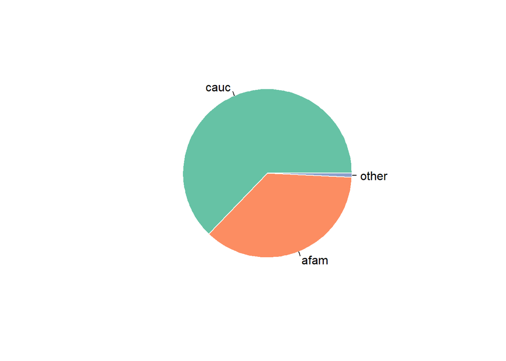

```r
#for ethnicity
pie(c(table(STAR$ethnicity)[[1]],table(STAR$ethnicity)[[2]],sum(table(STAR$ethnicity)[[3]]+table(STAR$ethnicity)[[4]]+table(STAR$ethnicity)[[5]]+table(STAR$ethnicity)[[6]])), labels = c("cauc", "afam", "other"), border="white", col=myPalette)
```

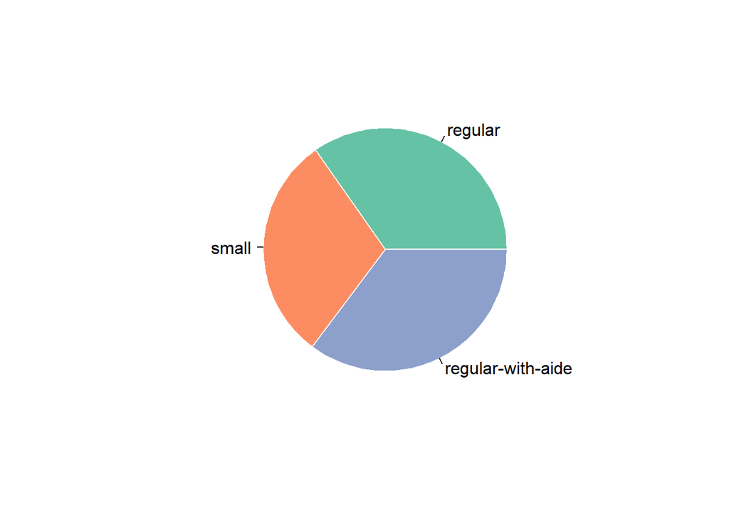

```r
#for birth

#for stark
pie(table(STAR$stark), labels = c("regular","small","regular-with-aide"), border="white", col=myPalette )
```

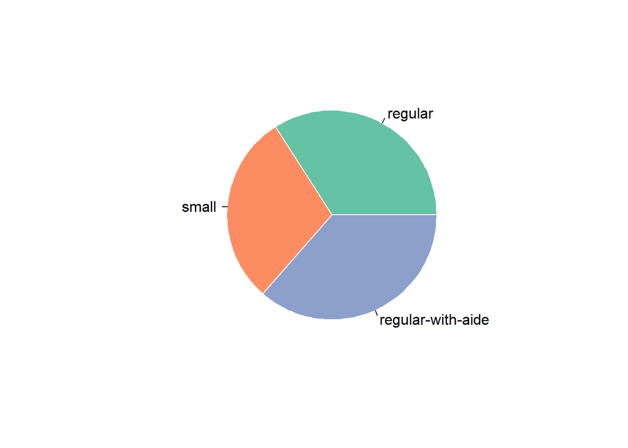

```r
#for star2
pie(table(STAR$star2), labels = c("regular","small","regular-with-aide"), border="white", col=myPalette )
```

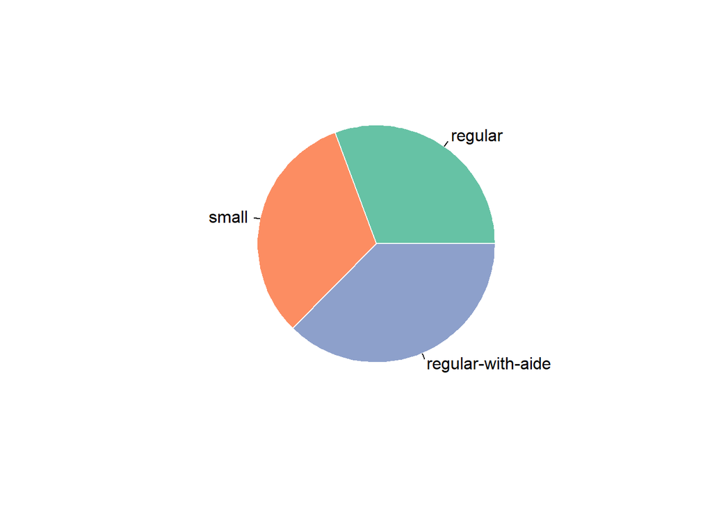

```r
#for star3
pie(table(STAR$star3), labels = c("regular","small","regular-with-aide"), border="white", col=myPalette )
```

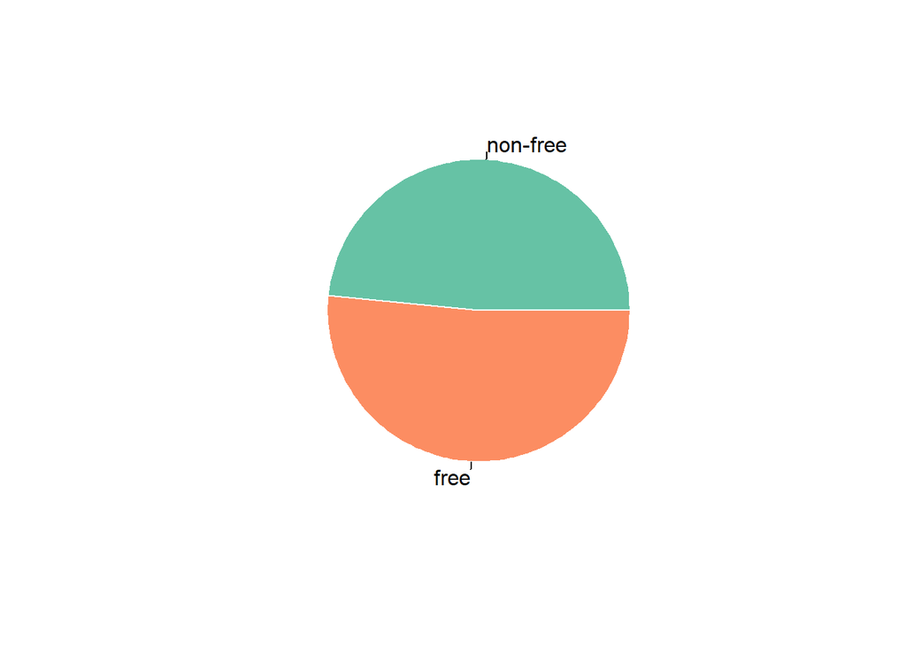

```r
#for lunch1
pie(table(STAR$lunch1), labels = c("non-free","free"), border="white", col=myPalette )
```

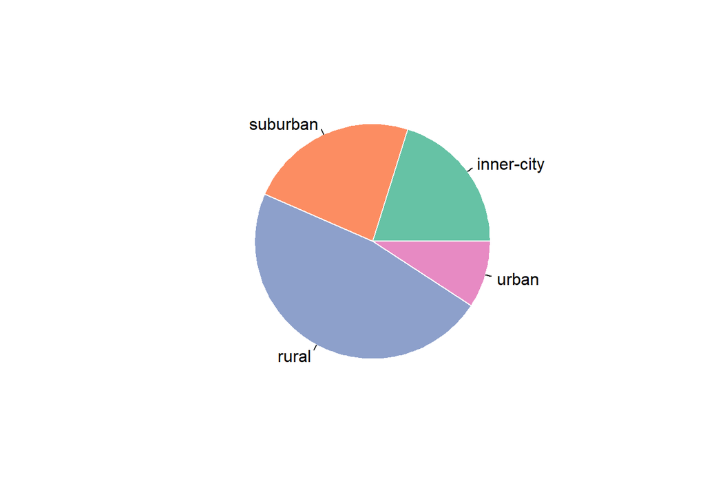

```r
#for school1
pie(table(STAR$school1), labels = c("inner-city","suburban","rural", "urban"), border="white", col=myPalette )
```

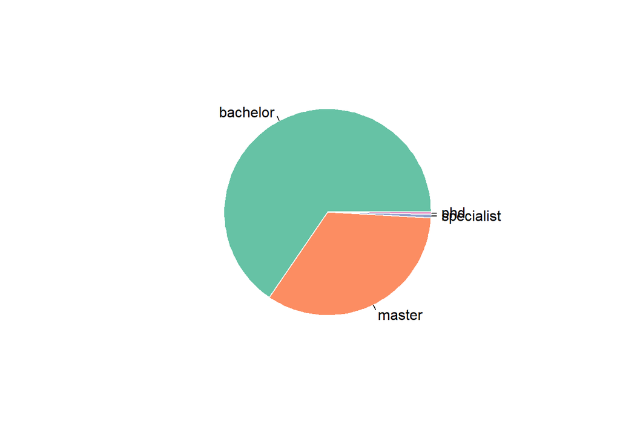

```r
#for degree1
pie(table(STAR$degree1), labels = c("bachelor","master","specialist", "phd"), border="white", col=myPalette )
```

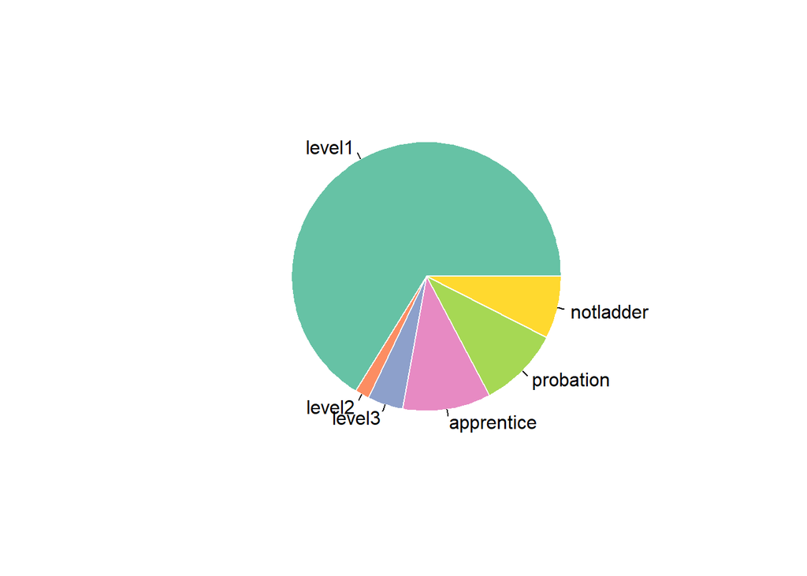

```r
#for ladder1
pie(table(STAR$ladder1), labels = c("level1","level2","level3", "apprentice", "probation", "notladder"), border="white", col=myPalette )
```

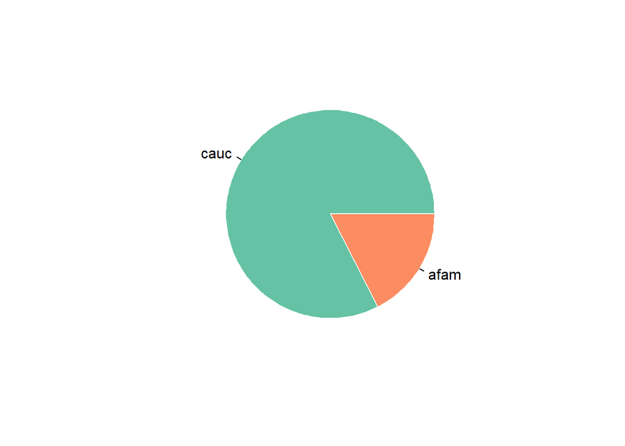

```r
#for tethnicity1
pie(table(STAR$tethnicity1), labels = c("cauc","afam"), border="white", col=myPalette )
```

Then we give the boxplots to show the relationships between STAR class type with the grade of read, and math respectively. We only show the boxplot of “star1” and “math1”, and others will be shown in appendix.

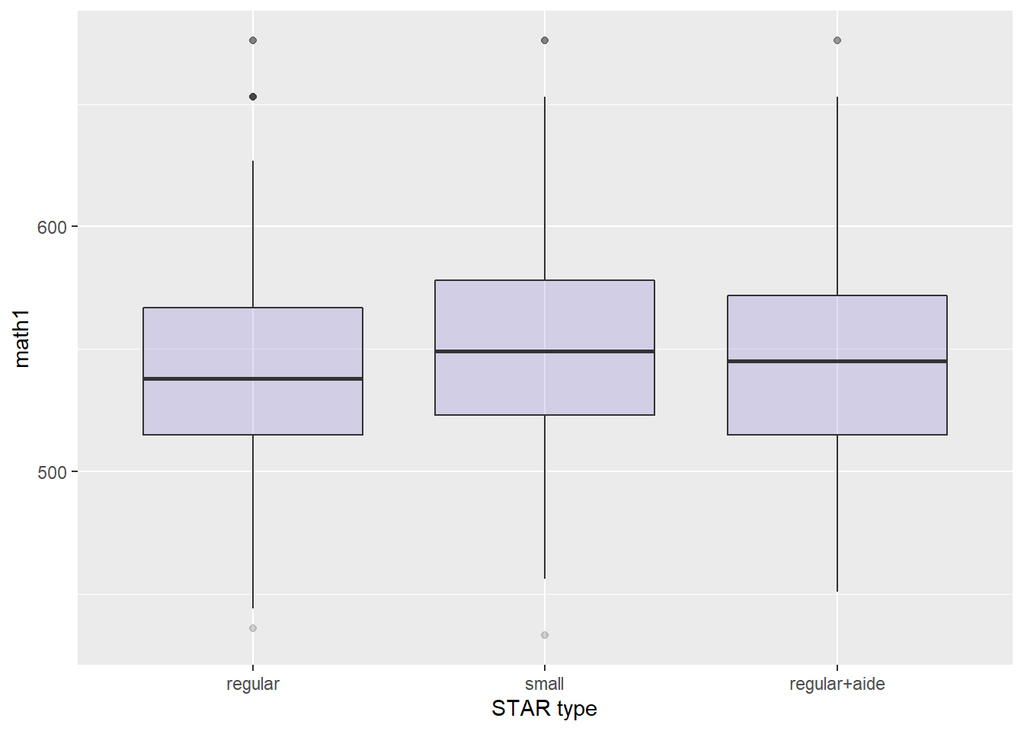

```r
library(ggplot2)
ggplot(na.omit(STAR), aes(x=star1, y=math1)) +
    geom_boxplot(fill="slateblue", alpha=0.2) +
    xlab("STAR type")
```

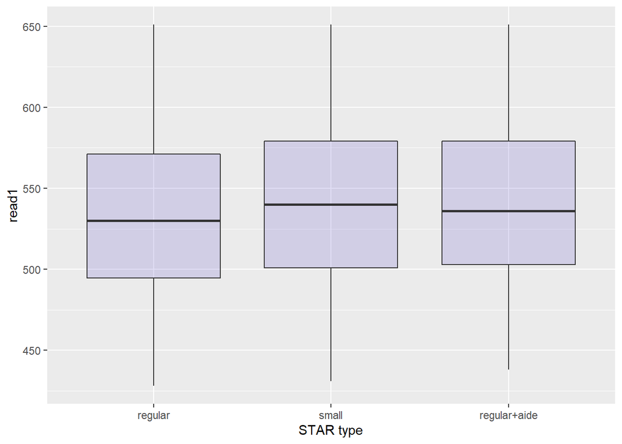

```r
#appendix
#star1 for read1
ggplot(na.omit(STAR), aes(x=star1, y=read1)) +
    geom_boxplot(fill="slateblue", alpha=0.2) +
    xlab("STAR type")
```

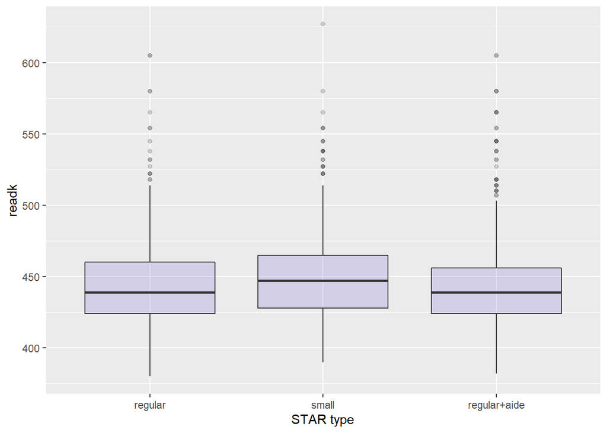

```r
#stark for readk
ggplot(na.omit(STAR), aes(x=stark, y=readk)) +
    geom_boxplot(fill="slateblue", alpha=0.2) +
    xlab("STAR type")
```

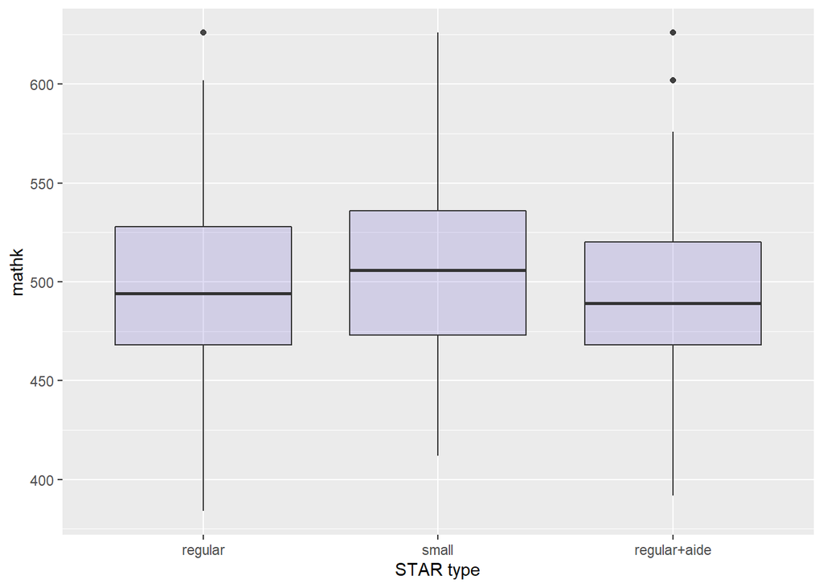

```r
#stark for mathk
ggplot(na.omit(STAR), aes(x=stark, y=mathk)) +
    geom_boxplot(fill="slateblue", alpha=0.2) +
    xlab("STAR type")
```

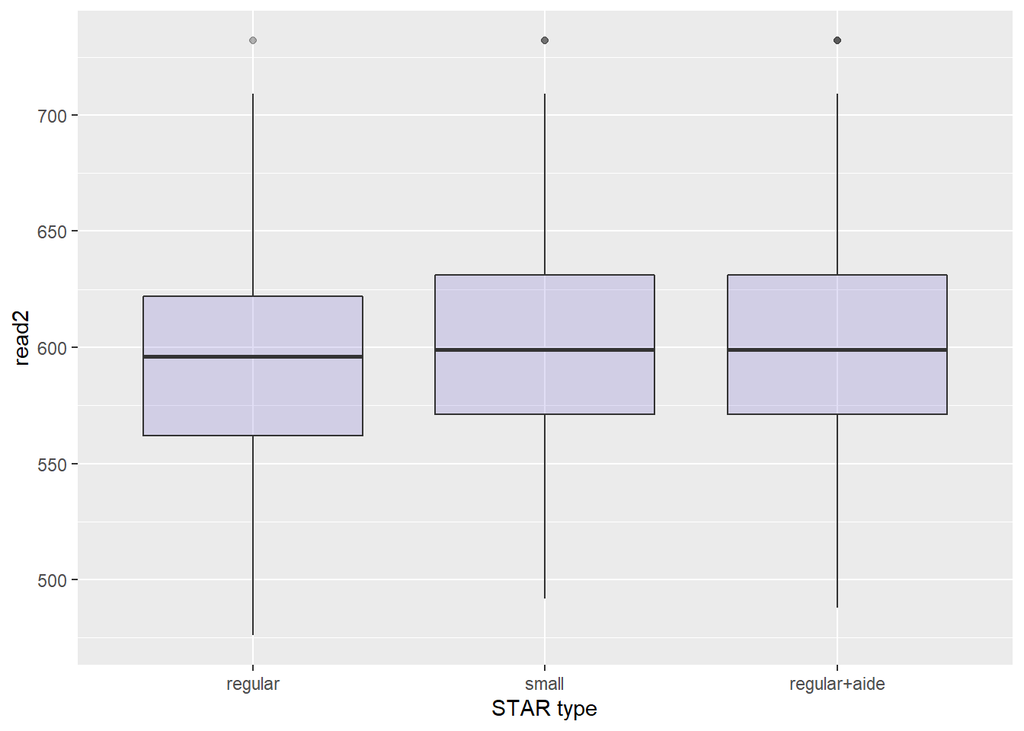

```r
#star2 for read2
ggplot(na.omit(STAR), aes(x=star2, y=read2)) +
    geom_boxplot(fill="slateblue", alpha=0.2) +
    xlab("STAR type")
```

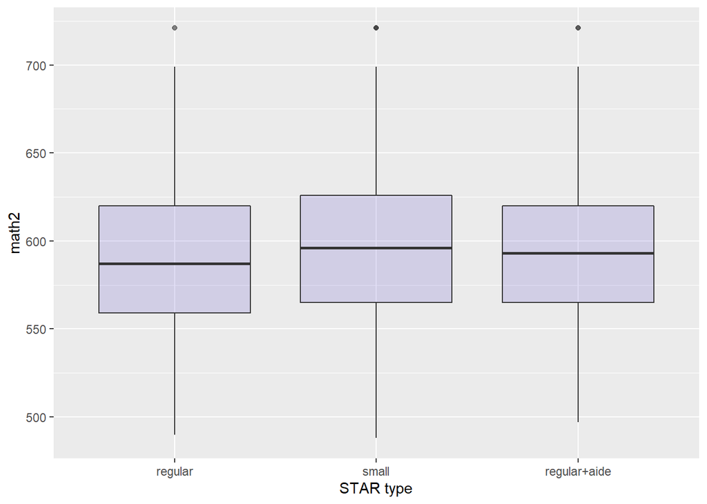

```r
#star2 for math2
ggplot(na.omit(STAR), aes(x=star2, y=math2)) +
    geom_boxplot(fill="slateblue", alpha=0.2) +
    xlab("STAR type")
```

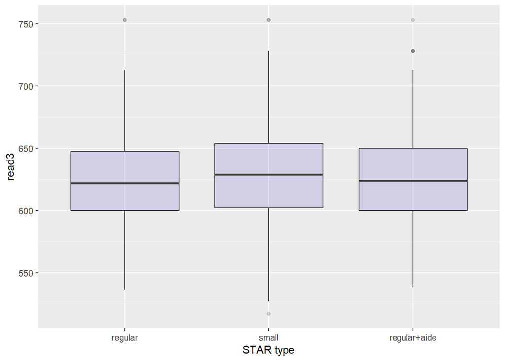

```r
#star3 for read3
ggplot(na.omit(STAR), aes(x=star3, y=read3)) +
    geom_boxplot(fill="slateblue", alpha=0.2) +
    xlab("STAR type")
```

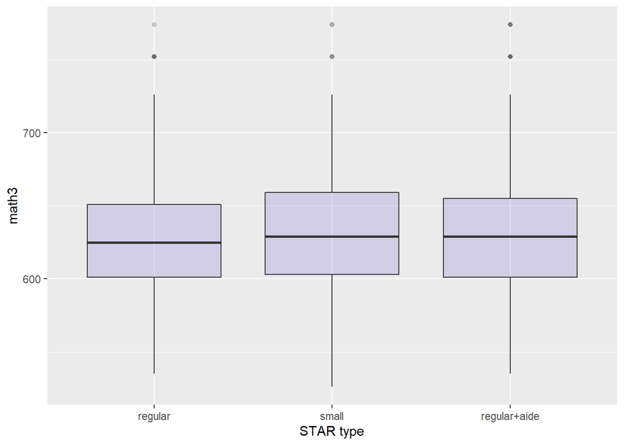

```r
#star3 for read3
ggplot(na.omit(STAR), aes(x=star3, y=math3)) +
    geom_boxplot(fill="slateblue", alpha=0.2) +
    xlab("STAR type")
```

From the boxplot, we can see that children in small type class have a better performance in read and math compared with classes of other types, and with the higher grade, the grades of children in classes of different types are closer.  
Next, we will plot the boxplot of “math1” with other qualatative variables, to find out whether these factors affect math grade.

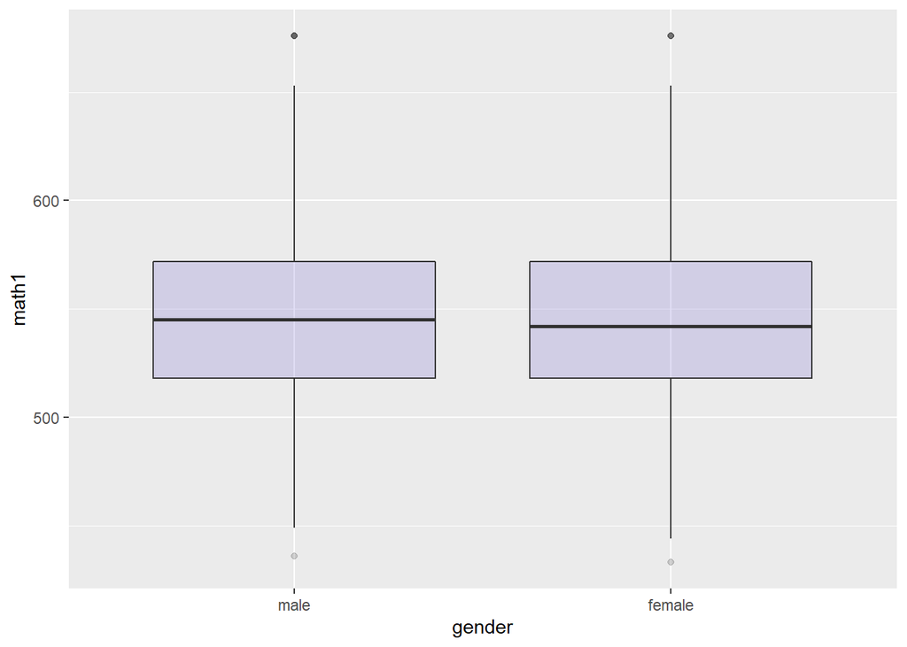

```r
library(ggplot2)
#gender
ggplot(na.omit(STAR), aes(x=gender, y=math1)) +
    geom_boxplot(fill="slateblue", alpha=0.2) +
    xlab("gender")
```

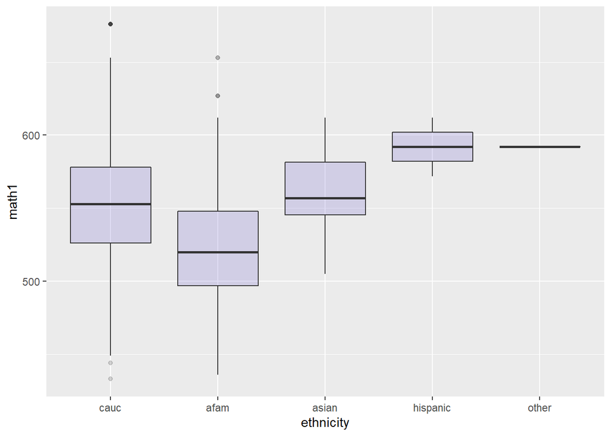

```r
#ethnicity
ggplot(na.omit(STAR), aes(x=ethnicity, y=math1)) +
    geom_boxplot(fill="slateblue", alpha=0.2) +
    xlab("ethnicity")
```

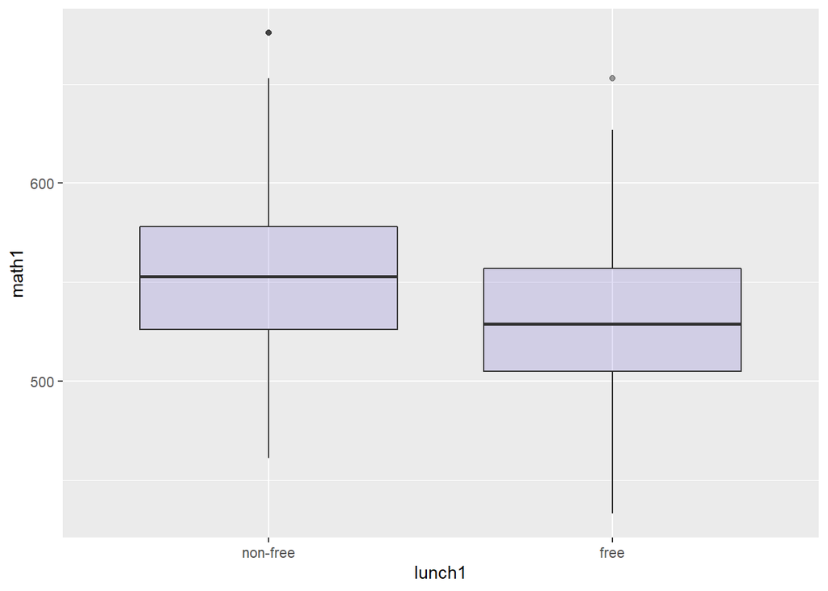

```r
#lunch1
ggplot(na.omit(STAR), aes(x=lunch1, y=math1)) +
    geom_boxplot(fill="slateblue", alpha=0.2) +
    xlab("lunch1")
```